# ME314 2019 Exam

Ken Benoit

**INSTRUCTIONS:** Answer **four** of the **five** questions. If you answer five, we will base your grade on the best four of five. Each of your four best questions is weighted equally in the determination of your overall grade. (**25 points each**)

### Question 1

Using the `Hitters` dataset (from the **ISLR** package), you will be predicting `Salary` based on the other variables in this data set.

```r
data(Hitters, package = "ISLR")
summary(Hitters)
```

```
##      AtBat            Hits         HmRun            Runs
##  Min.   : 16.0   Min.   :  1   Min.   : 0.00   Min.   :  0.00
##  1st Qu.:255.2   1st Qu.: 64   1st Qu.: 4.00   1st Qu.: 30.25
##  Median :379.5   Median : 96   Median : 8.00   Median : 48.00
##  Mean   :380.9   Mean   :101   Mean   :10.77   Mean   : 50.91
##  3rd Qu.:512.0   3rd Qu.:137   3rd Qu.:16.00   3rd Qu.: 69.00
##  Max.   :687.0   Max.   :238   Max.   :40.00   Max.   :130.00
##
##       RBI             Walks            Years            CAtBat
##  Min.   :  0.00   Min.   :  0.00   Min.   : 1.000   Min.   :   19.0
##  1st Qu.: 28.00   1st Qu.: 22.00   1st Qu.: 4.000   1st Qu.:  816.8
##  Median : 44.00   Median : 35.00   Median : 6.000   Median : 1928.0
##  Mean   : 48.03   Mean   : 38.74   Mean   : 7.444   Mean   : 2648.7
##  3rd Qu.: 64.75   3rd Qu.: 53.00   3rd Qu.:11.000   3rd Qu.: 3924.2
##  Max.   :121.00   Max.   :105.00   Max.   :24.000   Max.   :14053.0
##
##      CHits            CHmRun           CRuns             CRBI
##  Min.   :   4.0   Min.   :  0.00   Min.   :   1.0   Min.   :   0.00
##  1st Qu.: 209.0   1st Qu.: 14.00   1st Qu.: 100.2   1st Qu.:  88.75
##  Median : 508.0   Median : 37.50   Median : 247.0   Median : 220.50
##  Mean   : 717.6   Mean   : 69.49   Mean   : 358.8   Mean   : 330.12
##  3rd Qu.:1059.2   3rd Qu.: 90.00   3rd Qu.: 526.2   3rd Qu.: 426.25
##  Max.   :4256.0   Max.   :548.00   Max.   :2165.0   Max.   :1659.00
##
##      CWalks        League  Division    PutOuts          Assists
##  Min.   :   0.00   A:175   E:157    Min.   :   0.0   Min.   :  0.0
##  1st Qu.:  67.25   N:147   W:165    1st Qu.: 109.2   1st Qu.:  7.0
##  Median : 170.50                    Median : 212.0   Median : 39.5
##  Mean   : 260.24                    Mean   : 288.9   Mean   :106.9
##  3rd Qu.: 339.25                    3rd Qu.: 325.0   3rd Qu.:166.0
##  Max.   :1566.00                    Max.   :1378.0   Max.   :492.0
##
##      Errors          Salary       NewLeague
##  Min.   : 0.00   Min.   :  67.5   A:176
##  1st Qu.: 3.00   1st Qu.: 190.0   N:146
##  Median : 6.00   Median : 425.0
##  Mean   : 8.04   Mean   : 535.9
##  3rd Qu.:11.00   3rd Qu.: 750.0
##  Max.   :32.00   Max.   :2460.0
##                  NA's   :59
```

```r
dim(Hitters)
```

```
## [1] 322  20
```

1. For each predictor, fit a simple (single-variable) linear regression model to predict the response. In which of the models is there a statistically significant association between the predictor and the response?

#The models, which precitors are AtBat, Hits, HmRun, Runs, RBI, Walks, Years, CAtBat, CHits, CHmRun, CRuns, CRBI, CWalks, PutOuts respectively, have statistically significant association between the predictor and the response because their coefficients are significant at a significance level than 0.001. The model of DivisionW also have statistically significant association between the predictor and the response, and their coefficient is significant at less than 0.01.

```r
val.names <- colnames(Hitters)
univariate.coefs <- vector()

for (val in val.names) {
  if (val != "Salary") {
    print(val)
    m <- lm(Hitters$Salary ~ Hitters[, val])
    univariate.coefs <- c(univariate.coefs, coef(m)[2])
    print(summary(m))
  }
}
```

```
## [1] "AtBat"
##
## Call:
## lm(formula = Hitters$Salary ~ Hitters[, val])
##
## Residuals:
##     Min      1Q  Median      3Q     Max
## -723.21 -237.53  -58.98  176.82 2055.22
##
## Coefficients:
##                Estimate Std. Error t value Pr(>|t|)
## (Intercept)     47.9381    74.8184   0.641    0.522
## Hitters[, val]   1.2090     0.1742   6.942 3.07e-11 ***
## ---
## Signif. codes:  0 '***' 0.001 '**' 0.01 '*' 0.05 '.' 0.1 ' ' 1
##
## Residual standard error: 415.3 on 261 degrees of freedom
##   (59 observations deleted due to missingness)
## Multiple R-squared:  0.1558, Adjusted R-squared:  0.1526
## F-statistic: 48.18 on 1 and 261 DF,  p-value: 3.065e-11
##
## [1] "Hits"
##
## Call:
## lm(formula = Hitters$Salary ~ Hitters[, val])
##
## Residuals:
##     Min      1Q  Median      3Q     Max
## -893.99 -245.63  -59.08  181.12 2059.90
##
## Coefficients:
##                Estimate Std. Error t value Pr(>|t|)
## (Intercept)     63.0488    64.9822   0.970    0.333
## Hitters[, val]   4.3854     0.5561   7.886 8.53e-14 ***
## ---
## Signif. codes:  0 '***' 0.001 '**' 0.01 '*' 0.05 '.' 0.1 ' ' 1
##
## Residual standard error: 406.2 on 261 degrees of freedom
##   (59 observations deleted due to missingness)
## Multiple R-squared:  0.1924, Adjusted R-squared:  0.1893
```

[output cut: 343 more lines]

```
## Residuals:
##    Min     1Q Median     3Q    Max
## -469.6 -345.8 -112.1  215.4 1922.9
##
## Coefficients:
##                 Estimate Std. Error t value Pr(>|t|)
## (Intercept)      537.113     38.064  14.111   <2e-16 ***
## Hitters[, val]N   -2.559     55.887  -0.046    0.964
## ---
## Signif. codes:  0 '***' 0.001 '**' 0.01 '*' 0.05 '.' 0.1 ' ' 1
##
## Residual standard error: 452 on 261 degrees of freedom
##   (59 observations deleted due to missingness)
## Multiple R-squared:  8.034e-06,  Adjusted R-squared:  -0.003823
## F-statistic: 0.002097 on 1 and 261 DF,  p-value: 0.9635
```

2. Fit a multiple regression model to predict the response using all of the predictors. Describe your results. For which predictors can we reject the null hypothesis $H_0 : \beta_j = 0$?

#(Description of result) # The model is predicting the response Salary based on the known predictors, which are including: AtBat ,Hits,HmRun,Runs,RBI,Walks,Years,CAtBat,CHits,CHmRun,CRuns,CRBI,CWalks,League,Division,PutOuts,Assists,Errors,NewLeague.

#COEFFICIENTS:Holding all other covariates constant, when AtBat increases one unit, unit of Salary increases -1.97987. The coefficient is signficant at less than 0.1.Holding all other covariates constant, when Hits increases one unit, unit of Salary increases 7.50077. The coefficient is signficant at less than 0.01.Holding all other covariates constant, when HmRun increases one unit, unit of Salary increases 4.33088. The coefficient is signficant at less than 1.Holding all other covariates constant, when Runs increases one unit, unit of Salary increases -2.37621. The coefficient is signficant at less than 1.Holding all other covariates constant, when RBI increases one unit, unit of Salary increases -1.04496. The coefficient is signficant at less than 1.Holding all other covariates constant, when Walks increases one unit, unit of Salary increases 6.23129. The coefficient is signficant at less than 0.001.Holding all other covariates constant, when Years increases one unit, unit of Salary increases -3.48905. The coefficient is signficant at less than 1.Holding all other covariates constant, when CAtBat increases one unit, unit of Salary increases -0.17134. The coefficient is signficant at less than 1.Holding all other covariates constant, when CHits increases one unit, unit of Salary increases 0.13399 . The coefficient is signficant at less than 1.Holding all other covariates constant, when CHmRun increases one unit, unit of Salary increases -0.17286. The coefficient is signficant at less than 1.Holding all other covariates constant, when CRuns increases one unit, unit of Salary increases 1.45430 . The coefficient is signficant at less than 0.1.Holding all other covariates constant, when CRBI increases one unit, unit of Salary increases 0.80771. The coefficient is signficant at less than 1.Holding all 1.Holding all other covariates constant, when CWalks increases one unit, unit of Salary increases -0.81157. The coefficient is signficant at less than 0.05.Holding all other covariates constant, when LeagueN increases one unit, unit of Salary increases 62.59942. The coefficient is signficant at less than 1.Holding all other covariates constant, when DivisionW increases one unit, unit of Salary increases -116.84925. The coefficient is signficant at less than 0.01.Holding all other covariates constant, when PutOuts increases one unit, unit of Salary increases 0.28189. The coefficient is signficant at less than 0.001.Holding all other covariates constant, when Assists increases one unit, unit of Salary increases 0.37107 . The coefficient is signficant at less than 0.1.Holding all other covariates constant, when Errors increases one unit, unit of Salary increases -3.36076. The coefficient is signficant at less than 1.Holding all other covariates constant, when NewLeagueN increases one unit, unit of Salary increases -24.76233. The coefficient is signficant at less than 1.

#RESIDUAL STANDARD ERROR: the RSE is 315.6 which means given that salary is in 1 units, actual salary from the true regression line by approximately an average of 315.6 units.

#R2 Proportion of variance explained by the model. It is not too close to 1 with particular high value. Then, the model leaves a substantial amount of the variation unexplained.

#(Predictors can be rejected to the null hypothesis) #The predictors can be rejected to the null hypothesis are AtBat, Hits, Walks, CWalks, DivisonW, and PutOuts. Their p values are at least less than 0.05, and it can show the predictors and reponse have statistically significant association.

```r
m2 <- lm(Salary ~ .-Salary, data=Hitters)
summary(m2)
```

```
##
## Call:
## lm(formula = Salary ~ . - Salary, data = Hitters)
##
## Residuals:
##     Min      1Q  Median      3Q     Max
## -907.62 -178.35  -31.11  139.09 1877.04
##
## Coefficients:
##               Estimate Std. Error t value Pr(>|t|)
## (Intercept)  163.10359   90.77854   1.797 0.073622 .
## AtBat         -1.97987    0.63398  -3.123 0.002008 **
## Hits           7.50077    2.37753   3.155 0.001808 **
## HmRun          4.33088    6.20145   0.698 0.485616
## Runs          -2.37621    2.98076  -0.797 0.426122
## RBI           -1.04496    2.60088  -0.402 0.688204
## Walks          6.23129    1.82850   3.408 0.000766 ***
## Years         -3.48905   12.41219  -0.281 0.778874
## CAtBat        -0.17134    0.13524  -1.267 0.206380
## CHits          0.13399    0.67455   0.199 0.842713
## CHmRun        -0.17286    1.61724  -0.107 0.914967
## CRuns          1.45430    0.75046   1.938 0.053795 .
## CRBI           0.80771    0.69262   1.166 0.244691
## CWalks        -0.81157    0.32808  -2.474 0.014057 *
## LeagueN       62.59942   79.26140   0.790 0.430424
## DivisionW   -116.84925   40.36695  -2.895 0.004141 **
## PutOuts        0.28189    0.07744   3.640 0.000333 ***
## Assists        0.37107    0.22120   1.678 0.094723 .
## Errors        -3.36076    4.39163  -0.765 0.444857
## NewLeagueN   -24.76233   79.00263  -0.313 0.754218
## ---
## Signif. codes:  0 '***' 0.001 '**' 0.01 '*' 0.05 '.' 0.1 ' ' 1
##
## Residual standard error: 315.6 on 243 degrees of freedom
##   (59 observations deleted due to missingness)
## Multiple R-squared:  0.5461, Adjusted R-squared:  0.5106
## F-statistic: 15.39 on 19 and 243 DF,  p-value: < 2.2e-16
```

3. How do your results from (a) compare to your results from (b)? Create a plot displaying the univariate regression coefficients from (a) on the $x$-axis, and the multiple regression coefficients from (b) on the $y$-axis. That is, each predictor is displayed as a single point in the plot. Its coefficient in a simple linear regression model is shown on the $x$-axis, and its coefficient estimate in the multiple linear regression model is shown on the $y$-axis. Hint: To get the coefficients from a fitted regression model, you can use `coef()`. Note that you are not interested in the intercept.

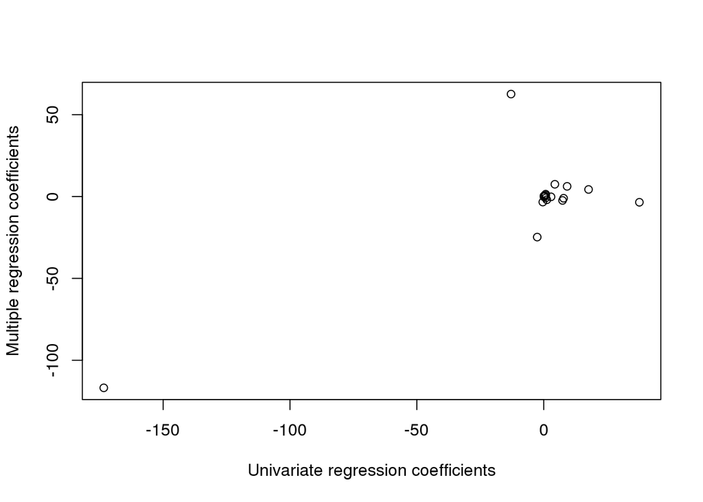

```r
multiple.coefs <- coef(m2)[2:length(coef(m2))]

plot(x=univariate.coefs, y=multiple.coefs, type='p', xlab="Univariate regression coefficients", ylab="Multiple regression coefficients")
```

### Question 2

Using the `Boston` data set, fit classification models in order to predict whether a given suburb has a crime rate above or below the median. Produce a confusion matrix for, and describe the findings from your model, for each of:

```r
data(Boston, package = "MASS")
summary(Boston)
```

```
##       crim                zn             indus            chas
##  Min.   : 0.00632   Min.   :  0.00   Min.   : 0.46   Min.   :0.00000
##  1st Qu.: 0.08204   1st Qu.:  0.00   1st Qu.: 5.19   1st Qu.:0.00000
##  Median : 0.25651   Median :  0.00   Median : 9.69   Median :0.00000
##  Mean   : 3.61352   Mean   : 11.36   Mean   :11.14   Mean   :0.06917
##  3rd Qu.: 3.67708   3rd Qu.: 12.50   3rd Qu.:18.10   3rd Qu.:0.00000
##  Max.   :88.97620   Max.   :100.00   Max.   :27.74   Max.   :1.00000
##       nox               rm             age              dis
##  Min.   :0.3850   Min.   :3.561   Min.   :  2.90   Min.   : 1.130
##  1st Qu.:0.4490   1st Qu.:5.886   1st Qu.: 45.02   1st Qu.: 2.100
##  Median :0.5380   Median :6.208   Median : 77.50   Median : 3.207
##  Mean   :0.5547   Mean   :6.285   Mean   : 68.57   Mean   : 3.795
##  3rd Qu.:0.6240   3rd Qu.:6.623   3rd Qu.: 94.08   3rd Qu.: 5.188
##  Max.   :0.8710   Max.   :8.780   Max.   :100.00   Max.   :12.127
##       rad              tax           ptratio          black
##  Min.   : 1.000   Min.   :187.0   Min.   :12.60   Min.   :  0.32
##  1st Qu.: 4.000   1st Qu.:279.0   1st Qu.:17.40   1st Qu.:375.38
##  Median : 5.000   Median :330.0   Median :19.05   Median :391.44
##  Mean   : 9.549   Mean   :408.2   Mean   :18.46   Mean   :356.67
##  3rd Qu.:24.000   3rd Qu.:666.0   3rd Qu.:20.20   3rd Qu.:396.23
##  Max.   :24.000   Max.   :711.0   Max.   :22.00   Max.   :396.90
##      lstat            medv
##  Min.   : 1.73   Min.   : 5.00
##  1st Qu.: 6.95   1st Qu.:17.02
##  Median :11.36   Median :21.20
##  Mean   :12.65   Mean   :22.53
##  3rd Qu.:16.95   3rd Qu.:25.00
##  Max.   :37.97   Max.   :50.00
```

```r
dim(Boston)
```

```
## [1] 506  14
```

1. linear regression. What is wrong with this model? # Linear regression model cannot predict whether the crime rate for each area is above or below the median because it can only predict continuous response values.

```r
lm.boston<- lm(crim ~ ., data = Boston)
summary(lm.boston)
```

```
##
## Call:
## lm(formula = crim ~ ., data = Boston)
##
## Residuals:
##    Min     1Q Median     3Q    Max
## -9.924 -2.120 -0.353  1.019 75.051
##
## Coefficients:
##               Estimate Std. Error t value Pr(>|t|)
## (Intercept)  17.033228   7.234903   2.354 0.018949 *
## zn            0.044855   0.018734   2.394 0.017025 *
## indus        -0.063855   0.083407  -0.766 0.444294
## chas         -0.749134   1.180147  -0.635 0.525867
## nox         -10.313535   5.275536  -1.955 0.051152 .
## rm            0.430131   0.612830   0.702 0.483089
## age           0.001452   0.017925   0.081 0.935488
## dis          -0.987176   0.281817  -3.503 0.000502 ***
## rad           0.588209   0.088049   6.680 6.46e-11 ***
## tax          -0.003780   0.005156  -0.733 0.463793
## ptratio      -0.271081   0.186450  -1.454 0.146611
## black        -0.007538   0.003673  -2.052 0.040702 *
## lstat         0.126211   0.075725   1.667 0.096208 .
## medv         -0.198887   0.060516  -3.287 0.001087 **
## ---
## Signif. codes:  0 '***' 0.001 '**' 0.01 '*' 0.05 '.' 0.1 ' ' 1
##
## Residual standard error: 6.439 on 492 degrees of freedom
## Multiple R-squared:  0.454,  Adjusted R-squared:  0.4396
## F-statistic: 31.47 on 13 and 492 DF,  p-value: < 2.2e-16
```

2. logistic regression # Finding from the model: There are only predictors which are zn, nox, dis, rad, tax, ptratio, black, and medv can reject the null hypothesis because their p-value is at least less than 0.05. These predictors have statistically significant associations with the response. In other words, these variables have statistically significant influences on the crime rate. # The diagonal elements on the confusion matrix are numbers of correct predictions. For instance, the number 234 on the top left corner means that 234 among the overall 253(234+19) areas that have a crime rate below the median are correctly predicted by the logistic model.

```r
Boston$crim.bin <- ifelse(Boston$crim > median(Boston$crim), 1, 0) #1 means Above, 0 means Below

glm.boston <- glm(crim.bin ~ . - crim, data= Boston, family=binomial)

summary(glm.boston)
```

```
##
## Call:
## glm(formula = crim.bin ~ . - crim, family = binomial, data = Boston)
##
## Deviance Residuals:
##     Min       1Q   Median       3Q      Max
## -2.3946  -0.1585  -0.0004   0.0023   3.4239
##
## Coefficients:
##               Estimate Std. Error z value Pr(>|z|)
## (Intercept) -34.103704   6.530014  -5.223 1.76e-07 ***
## zn           -0.079918   0.033731  -2.369  0.01782 *
## indus        -0.059389   0.043722  -1.358  0.17436
## chas          0.785327   0.728930   1.077  0.28132
## nox          48.523782   7.396497   6.560 5.37e-11 ***
## rm           -0.425596   0.701104  -0.607  0.54383
## age           0.022172   0.012221   1.814  0.06963 .
## dis           0.691400   0.218308   3.167  0.00154 **
## rad           0.656465   0.152452   4.306 1.66e-05 ***
## tax          -0.006412   0.002689  -2.385  0.01709 *
## ptratio       0.368716   0.122136   3.019  0.00254 **
## black        -0.013524   0.006536  -2.069  0.03853 *
## lstat         0.043862   0.048981   0.895  0.37052
## medv          0.167130   0.066940   2.497  0.01254 *
## ---
## Signif. codes:  0 '***' 0.001 '**' 0.01 '*' 0.05 '.' 0.1 ' ' 1
##
## (Dispersion parameter for binomial family taken to be 1)
##
##     Null deviance: 701.46  on 505  degrees of freedom
## Residual deviance: 211.93  on 492  degrees of freedom
## AIC: 239.93
##
## Number of Fisher Scoring iterations: 9
```

```r
# confusion matrix
pred.results <- predict(glm.boston, newdata=Boston, type='response')
pred.results <- ifelse(pred.results > 0.5, 1, 0) #1 means Above, 0 means Below
# The row is truth value, and the column is prediction value
table(data.frame(truth=Boston$crim.bin, prediction=pred.results))
```

```
##      prediction
## truth   0   1
##     0 234  19
##     1  24 229
```

**Note:** You do not have to split the data into test and training sets here. Just predict on the training sample, which consists of the entire dataset.

### Question 3

1. Give a standard error for the median of the `indus` variable from `data(Boston, package = "MASS")`. # The standard error for the median of the `indus` variable is 0.3821398

```r
data(Boston, package = "MASS")
dim(Boston)
```

```
## [1] 506  14
```

```r
indus.sd<- sd(Boston$indus)
indus.SEM <- 1.253*indus.sd/sqrt(506)
print(indus.SEM)
```

```
## [1] 0.3821398
```

2. Estimate a bootstrapped standard error for the coefficient of `medv` in a logistic regression model of the above/below median of crime binary variable from question 2, with `medv`, `indus`, `age`, `black`, and `ptratio` as predictors. Compare this to the asymptotic standard error from the maximum likelihood estimation (reported by `summary.glm()`).

```r
library(arm)
```

```r
Boston$crim.bin <- ifelse(Boston$crim > median(Boston$crim), 1, 0)
ses.medv <- vector()
# suppose we sample 500 times, and each time randomly draws 1000 rows with replacement.
for (i in 1:500) {
  sample.data <- Boston[sample(1:nrow(Boston), 1000, replace=T), ]
  glm.mod <- glm(crim.bin ~ medv+indus+age+black+ptratio, data= sample.data, family=binomial(link='logit'))
  ses.medv <- c(ses.medv, se.coef(glm.mod)['medv'])
}
se.medv <- mean(ses.medv)
print(se.medv)
```

```
## [1] 0.01401746
```

```r
glm.boston <- glm(crim.bin ~ medv+indus+age+black+ptratio, data= Boston, family=binomial(link='logit'))
summary(glm.boston)
```

```
##
## Call:
## glm(formula = crim.bin ~ medv + indus + age + black + ptratio,
##     family = binomial(link = "logit"), data = Boston)
##
## Deviance Residuals:
##     Min       1Q   Median       3Q      Max
## -3.2161  -0.5891  -0.0811   0.6108   2.2380
##
## Coefficients:
##              Estimate Std. Error z value Pr(>|z|)
## (Intercept) -2.383696   2.667672  -0.894  0.37156
## medv         0.061370   0.019482   3.150  0.00163 **
## indus        0.135512   0.026589   5.097 3.46e-07 ***
## age          0.043247   0.006185   6.992 2.71e-12 ***
## black       -0.015597   0.005442  -2.866  0.00416 **
## ptratio      0.127227   0.070994   1.792  0.07312 .
## ---
## Signif. codes:  0 '***' 0.001 '**' 0.01 '*' 0.05 '.' 0.1 ' ' 1
##
## (Dispersion parameter for binomial family taken to be 1)
##
##     Null deviance: 701.46  on 505  degrees of freedom
## Residual deviance: 401.09  on 500  degrees of freedom
## AIC: 413.09
##
## Number of Fisher Scoring iterations: 7
```

```r
print(se.coef(glm.boston)['medv'])
```

```
##       medv
## 0.01948167
```

```r
# The bootstrapped standard error for coefficient of `medv` (0.014) is smaller than the asymptotic standard error from MLE (0.019)
```

### Question 4

Using **quanteda**, construct an English language dictionary for “populism” for English, using the word patterns found in Appendix B of Rooduijn, Matthijs, and Teun Pauwels. 2011. “Measuring Populism: Comparing Two Methods of Content Analysis.” *West European Politics* 34(6): 1272–83.

Use this dictionary to measure the relative amount of populism, as a total of all words in, the `data_corpus_irishbudget2010` when these are grouped by political party. Hint: You will need to make two dfm objects, one for all words, and one for the dictionary, and get a proportion. Plot the proportions by party (using any method).

```r
library("quanteda")
populism.dict<- dictionary(list(Core = c("elit*","consensus*","undemocratic*","referend*","corrupt*","propagand*","politici*","*deceit*","*deceiv*","*betray*","shame*","scandal*","truth*","dishonest*"), Context = c("establishm*", "ruling*")))
irish<- dfm(data_corpus_irishbudget2010,group= "party")
dictionary_dfm <- dfm(data_corpus_irishbudget2010,groups= "party", dictionary = populism.dict)
dictionary_dfm
```

```
## Document-feature matrix of: 5 documents, 2 features (10.0% sparse).
## 5 x 2 sparse Matrix of class "dfm"
##        features
## docs    Core Context
##   FF       1       1
##   FG       7       1
##   Green    2       0
##   LAB      7       2
##   SF      12       4
```

```r
wgt<- dfm_weight(irish, scheme = "prop")
irish_wgt <- dfm_lookup(wgt , dictionary = populism.dict)

irish_wgt_df <- convert(irish_wgt, to = "data.frame")
irish_wgt_df
```

```
##   document         Core      Context
## 1       FF 0.0000656168 6.561680e-05
## 2       FG 0.0006378132 9.111617e-05
## 3    Green 0.0005111168 0.000000e+00
## 4      LAB 0.0005327245 1.522070e-04
## 5       SF 0.0010761367 3.587122e-04
```

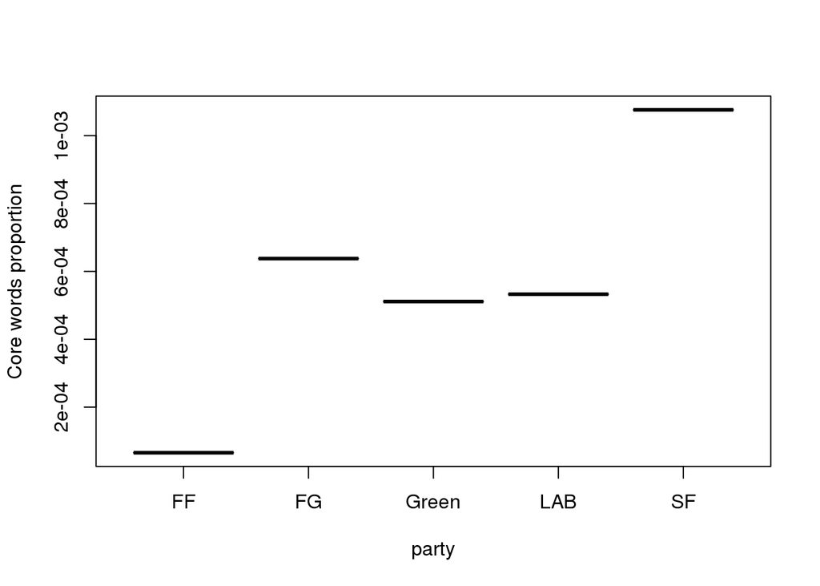

```r
irish_wgt_df <- cbind(irish_wgt_df, party = c("FF","FG","Green","LAB","SF"))

plot(irish_wgt_df$party, irish_wgt_df$Core, type="b",xlab="party",ylab="Core words proportion")
```

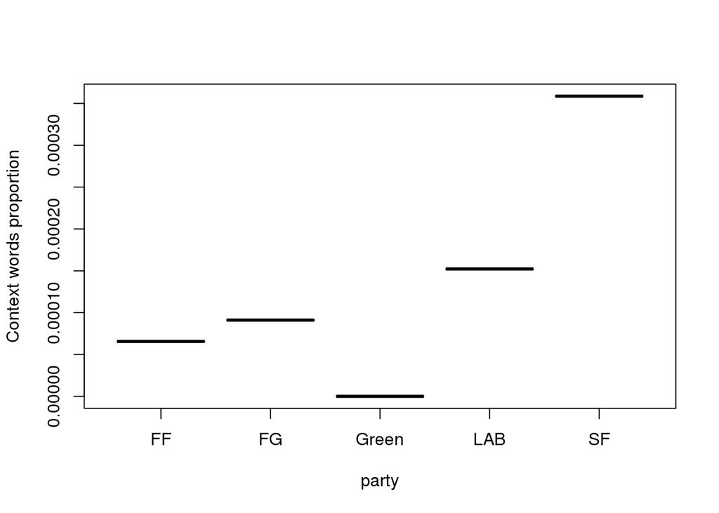

```r
plot(irish_wgt_df$party, irish_wgt_df$Context, type="b",xlab="party",ylab="Context words proportion")
```

### Question 5

Here we will use k-means clustering to see if we can produce groupings by party of the 1984 US House of Representatives, based on their voting records from 16 votes. This data is the object `HouseVotes84` from the `mlbench` package. Since this is stored as a list of factors, use the following code to transform it into a method that will work with the `kmeans()` function.

```r
data(HouseVotes84, package = "mlbench")
HouseVotes84num <- as.data.frame(lapply(HouseVotes84[, -1], unclass))
HouseVotes84num[is.na(HouseVotes84num)] <- 0
set.seed(2)  # make sure you do this before step b below
```

1. What does each line of that code snippet do, and why was this operation needed? What is the `-1` indexing for?
2. Perform a kmeans clustering on the votes only data, for 2 classes, after setting the seed to 2 as per above. Construct a table comparing the actual membership of the Congressperson’s party (you will find this as one of the variables in the `HouseVotes84` data) to the cluster assigned by the kmeans procedure. Report the
   1. accuracy
   2. precision
   3. recall
3. Repeat b twice more to produce three more confusion matrix tables, comparing the results. Are they the same? If not, why not?